# Final Team Project_A Machine Learning Approach to Global Obesity Classification

## Team "Obesity"

```python
# Load Libraries

import pandas as pd
import numpy as np
import seaborn as sns

from sklearn.model_selection import train_test_split
from sklearn.preprocessing import StandardScaler
from sklearn.svm import SVC
from sklearn.ensemble import RandomForestClassifier, VotingClassifier
from xgboost import XGBClassifier
from sklearn.metrics import accuracy_score, confusion_matrix, classification_report
from sklearn.svm import SVC
from sklearn.model_selection import GridSearchCV, train_test_split
from sklearn.ensemble import VotingClassifier
import matplotlib.pyplot as plt
```

# 1. Data Preparation

## 1.1 Main Dataset: Prevalence of adult overweight obesity among adults in countries around the world

```python
# Prepare data

#obesity_data = pd.read_csv('adult_obesity.csv', encoding='latin1')
obesity_data = pd.read_csv('https://raw.githubusercontent.com/erdenetuya2080/DATA5322-Machine-Learning-II/main/Practical%20Homework%20IV_Unsupervised%20Learning/Datasets/adult_obesity.csv', encoding='latin1')

obesity_clean = obesity_data[[
    'Country',
    'Year',
    'Age',
    'Males Overweight (BMI 25-29.9kg/m²)',
    'Males Obesity (BMI ?30kg/m²)',
    'Females Overweight (BMI 25-29.9kg/m²)',
    'Females Obesity (BMI ?30kg/m²)',
    'Adults Overweight (BMI 25-29.9kg/m²)',
    'Adults Obesity (BMI ?30kg/m²)'
]].rename(columns={
    'Males Overweight (BMI 25-29.9kg/m²)': 'Males_Overweight',
    'Males Obesity (BMI ?30kg/m²)': 'Males_Obesity',
    'Females Overweight (BMI 25-29.9kg/m²)': 'Females_Overweight',
    'Females Obesity (BMI ?30kg/m²)': 'Females_Obesity',
    'Adults Overweight (BMI 25-29.9kg/m²)': 'Adults_Overweight',
    'Adults Obesity (BMI ?30kg/m²)': 'Adults_Obesity'
})
cols_to_fix = ['Males_Overweight', 'Males_Obesity', 'Females_Overweight', 'Females_Obesity', 'Adults_Overweight', 'Adults_Obesity']

for col in cols_to_fix:
    obesity_clean[col] = obesity_clean[col].str.replace(',', '.', regex=False)
    obesity_clean[col] = pd.to_numeric(obesity_clean[col], errors='coerce')


# Drop missing rows
obesity_clean = obesity_clean.dropna()
obesity_clean = obesity_clean.dropna(subset=cols_to_fix)

# Filter only adult groups starting with '18'
obesity_clean = obesity_clean[obesity_clean['Age'].str.contains(r'^18', na=False)]

# Drop the Age column since we only kept adult rows
obesity_clean = obesity_clean.drop(columns=['Age'])

# Extract only the starting ("2017-2018" → 2017)
obesity_clean['Year'] = obesity_clean['Year'].str.extract(r'(\d{4})').astype(int)
obesity_clean.info()
obesity_clean.head()
```

```
<class 'pandas.core.frame.DataFrame'>
Index: 80 entries, 0 to 247
Data columns (total 8 columns):
 #   Column              Non-Null Count  Dtype
---  ------              --------------  -----
 0   Country             80 non-null     object
 1   Year                80 non-null     int32
 2   Males_Overweight    80 non-null     float64
 3   Males_Obesity       80 non-null     float64
 4   Females_Overweight  80 non-null     float64
 5   Females_Obesity     80 non-null     float64
 6   Adults_Overweight   80 non-null     float64
 7   Adults_Obesity      80 non-null     float64
dtypes: float64(6), int32(1), object(1)
memory usage: 5.3+ KB
```

|  | Country | Year | Males_Overweight | Males_Obesity | Females_Overweight | Females_Obesity | Adults_Overweight | Adults_Obesity |
| --- | --- | --- | --- | --- | --- | --- | --- | --- |
| 0 | Afghanistan | 2018 | 25.9 | 11.9 | 25.6 | 23.5 | 25.8 | 17.0 |
| 2 | Algeria | 2016 | 34.2 | 14.1 | 33.2 | 30.1 | 33.8 | 21.8 |
| 4 | Andorra | 2017 | 42.5 | 13.0 | 27.0 | 14.4 | 35.2 | 13.6 |
| 6 | Anguilla | 2016 | 36.0 | 30.4 | 27.4 | 46.5 | 31.7 | 38.5 |
| 8 | Argentina | 2018 | 38.7 | 31.4 | 29.1 | 33.4 | 33.7 | 32.4 |

Result: The resulting dataset is a clean, numeric collection of adult only obesity indicators, including male, female, and overall overweight and obesity rates, organized by country and year.

## 1.2 Supporting Dataset 2: World Development Indicators

```python
# Prepare data
world_data=pd.read_csv('World_data.csv')

# Drop unnecessary columns
world_data_cleaned = world_data.drop(columns=['Country Code', 'Series Code'])

world_long = pd.melt(
    world_data_cleaned,
    id_vars=['Country Name', 'Series Name'],
    var_name='Year',
    value_name='Value'
)

# Extract numeric year
world_long['Year'] = world_long['Year'].str.extract(r'(\d{4})').astype('Int64')

# Drop rows with missing key identifiers
world_long = world_long.dropna(subset=['Country Name', 'Series Name'])
world_long.info()

# Replace '..' with NaN and convert Value column to numeric
world_long['Value'] = pd.to_numeric(world_long['Value'], errors='coerce')

# Pivot the table so each indicator becomes a column
world_wide = world_long.pivot_table(
    index=['Country Name', 'Year'],
    columns='Series Name',
    values='Value'
).reset_index()

# Clean column names
world_wide.columns.name = None  # remove the pivoted name
world_wide.columns = [col.strip().replace(' ', '_') for col in world_wide.columns]

# Renaming
world_wide = world_wide.rename(columns={
    'Current_health_expenditure_per_capita_(current_US$)': 'Health_Expenditure',
    'GDP_per_capita_(current_US$)': 'GDP_Per_Capita',
    'Literacy_rate,_adult_total_(%_of_people_ages_15_and_above)': 'Literacy_Rate',
    'Physicians_(per_1,000_people)': 'Physicians_per_1000',
    'Urban_population_(%_of_total_population)': 'Urban_Pop_Percent'
})
# Dropping na values
world_wide_cleaned = world_wide.dropna(subset=[
    'Country_Name',
    'Year',
    'Health_Expenditure',
    'GDP_Per_Capita',
    'Literacy_Rate',
    'Physicians_per_1000',
    'Urban_Pop_Percent'
])
# Convert numeric columns from string to float
columns_to_convert = ['Health_Expenditure', 'GDP_Per_Capita', 'Literacy_Rate', 'Physicians_per_1000', 'Urban_Pop_Percent']

for col in columns_to_convert:
    world_wide_cleaned[col] = pd.to_numeric(world_wide_cleaned[col], errors='coerce')

# Drop any new NaNs that appear due to conversion
world_wide_cleaned = world_wide_cleaned.dropna(subset=columns_to_convert)
world_wide_cleaned.info()
world_wide_cleaned.head()
```

```
<class 'pandas.core.frame.DataFrame'>
Index: 30590 entries, 0 to 30699
Data columns (total 4 columns):
 #   Column        Non-Null Count  Dtype
---  ------        --------------  -----
 0   Country Name  30590 non-null  object
 1   Series Name   30590 non-null  object
 2   Year          30590 non-null  Int64
 3   Value         30590 non-null  object
dtypes: Int64(1), object(3)
memory usage: 1.2+ MB
<class 'pandas.core.frame.DataFrame'>
Index: 612 entries, 11 to 6067
Data columns (total 7 columns):
 #   Column               Non-Null Count  Dtype
---  ------               --------------  -----
 0   Country_Name         612 non-null    object
 1   Year                 612 non-null    Int64
 2   Health_Expenditure   612 non-null    float64
 3   GDP_Per_Capita       612 non-null    float64
 4   Literacy_Rate        612 non-null    float64
 5   Physicians_per_1000  612 non-null    float64
 6   Urban_Pop_Percent    612 non-null    float64
dtypes: Int64(1), float64(5), object(1)
memory usage: 38.8+ KB
```

|  | Country_Name | Year | Health_Expenditure | GDP_Per_Capita | Literacy_Rate | Physicians_per_1000 | Urban_Pop_Percent |
| --- | --- | --- | --- | --- | --- | --- | --- |
| 11 | Afghanistan | 2011 | 52.187218 | 606.694676 | 31.000000 | 0.259000 | 23.948000 |
| 15 | Afghanistan | 2015 | 59.919605 | 565.569730 | 33.753841 | 0.291000 | 24.803000 |
| 33 | Africa Eastern and Southern | 2010 | 104.119647 | 1601.727748 | 64.809998 | 0.104126 | 32.195595 |
| 43 | Africa Eastern and Southern | 2020 | 81.551895 | 1344.080962 | 72.855759 | 0.218133 | 36.884034 |
| 46 | Africa Western and Central | 2000 | 18.199851 | 516.932316 | 47.577381 | 0.192887 | 35.341698 |

Result: This dataset contains clean, numeric, country-level indicators such as health expenditure, GDP per capita, literacy rate, physician density, and urban population percentage by year.

## 1.3 Supporting Dataset 3: Women Empowerment

```python
# Load and clean women empowerment data
women_data = pd.read_csv('Most_Recent_Political_Empowerment_Index_by_Country.csv')
women_data.drop(columns=['Code'], inplace=True)
women_data.rename(columns={'Entity': 'Country'}, inplace=True)

# Results
women_data.info()
women_data.head()
```

```
<class 'pandas.core.frame.DataFrame'>
RangeIndex: 211 entries, 0 to 210
Data columns (total 3 columns):
 #   Column                                                  Non-Null Count  Dtype
---  ------                                                  --------------  -----
 0   Country                                                 211 non-null    object
 1   Year                                                    211 non-null    int64
 2   Women's political empowerment index (central estimate)  211 non-null    float64
dtypes: float64(1), int64(1), object(1)
memory usage: 5.1+ KB
```

|  | Country | Year | Women's political empowerment index (central estimate) |
| --- | --- | --- | --- |
| 0 | Afghanistan | 2024 | 0.045000 |
| 1 | Africa | 2024 | 0.672911 |
| 2 | Africa (population-weighted) | 2024 | 0.678396 |
| 3 | Albania | 2024 | 0.905000 |
| 4 | Algeria | 2024 | 0.636000 |

## 1.3 Merge Datasets

```python
# Get latest World Bank entry per country
latest_world = world_wide_cleaned.sort_values('Year').drop_duplicates('Country_Name', keep='last')

# Merge with obesity data (Country only)
obesity_world_finaldata = pd.merge(
    obesity_clean,
    latest_world,
    left_on='Country',
    right_on='Country_Name',
    how='inner'
)
obesity_world_finaldata.drop(columns=['Country_Name', 'Year_y'], inplace=True)
obesity_world_finaldata.rename(columns={'Year_x': 'Year'}, inplace=True)

# Merge Dataset
obesity_world_enricheddata = pd.merge(
    obesity_world_finaldata,
    women_data[['Country', "Women's political empowerment index (central estimate)"]],
    on='Country',
    how='inner'
)

# Result
obesity_world_enricheddata.info()
obesity_world_enricheddata.head()
```

```
<class 'pandas.core.frame.DataFrame'>
RangeIndex: 47 entries, 0 to 46
Data columns (total 14 columns):
 #   Column                                                  Non-Null Count  Dtype
---  ------                                                  --------------  -----
 0   Country                                                 47 non-null     object
 1   Year                                                    47 non-null     int32
 2   Males_Overweight                                        47 non-null     float64
 3   Males_Obesity                                           47 non-null     float64
 4   Females_Overweight                                      47 non-null     float64
 5   Females_Obesity                                         47 non-null     float64
 6   Adults_Overweight                                       47 non-null     float64
 7   Adults_Obesity                                          47 non-null     float64
 8   Health_Expenditure                                      47 non-null     float64
 9   GDP_Per_Capita                                          47 non-null     float64
 10  Literacy_Rate                                           47 non-null     float64
 11  Physicians_per_1000                                     47 non-null     float64
 12  Urban_Pop_Percent                                       47 non-null     float64
 13  Women's political empowerment index (central estimate)  47 non-null     float64
dtypes: float64(12), int32(1), object(1)
memory usage: 5.1+ KB
```

|  | Country | Year | Males_Overweight | Males_Obesity | Females_Overweight | Females_Obesity | Adults_Overweight | Adults_Obesity | Health_Expenditure | GDP_Per_Capita | Literacy_Rate | Physicians_per_1000 | Urban_Pop_Percent | Women's political empowerment index (central estimate) |
| --- | --- | --- | --- | --- | --- | --- | --- | --- | --- | --- | --- | --- | --- | --- |
| 0 | Afghanistan | 2018 | 25.9 | 11.9 | 25.6 | 23.5 | 25.8 | 17.0 | 59.919605 | 565.569730 | 33.753841 | 0.2910 | 24.803 | 0.045 |
| 1 | Algeria | 2016 | 34.2 | 14.1 | 33.2 | 30.1 | 33.8 | 21.8 | 271.537781 | 4577.210292 | 81.407837 | 1.7320 | 72.629 | 0.636 |
| 2 | Argentina | 2018 | 38.7 | 31.4 | 29.1 | 33.4 | 33.7 | 32.4 | 668.793091 | 7141.475077 | 97.000000 | 3.2481 | 89.329 | 0.849 |
| 3 | Armenia | 2016 | 31.4 | 14.0 | 25.1 | 25.0 | 28.2 | 19.5 | 409.801453 | 3869.053739 | 100.000000 | 2.9720 | 63.103 | 0.892 |
| 4 | Azerbaijan | 2017 | 38.8 | 14.7 | 30.9 | 26.5 | 34.8 | 20.6 | 199.257462 | 4805.753718 | 100.000000 | 3.1110 | 56.031 | 0.621 |

Result: The final merged dataset combines adult obesity rates with the most recent country-level indicators such as GDP, health expenditure, and literacy rate, resulting in a dataset with 47 records and 14 variables.

# 2. Exploring the Data

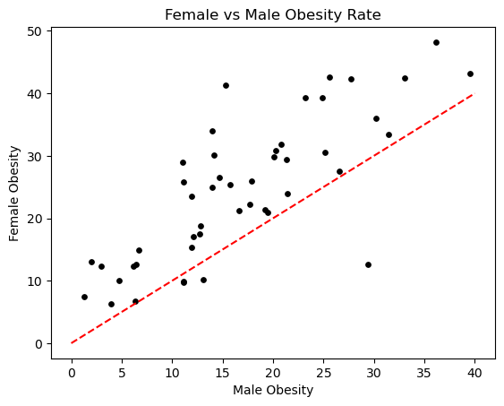

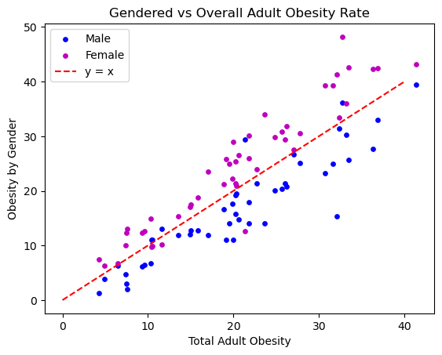

```python
# Plot: Female vs Male Obesity
fig, ax = plt.subplots(1, 1)
ax.scatter(obesity_world_enricheddata['Males_Obesity'], obesity_world_enricheddata['Females_Obesity'], c="k", s=15)
ax.set_xlabel('Male Obesity')
ax.set_ylabel('Female Obesity')
ax.set_title("Female vs Male Obesity Rate")
ax.plot(np.arange(0, 41), np.arange(0, 41), linestyle='dashed', color='r')  # y = x line

# Plot: Gendered vs Overall Adult Obesity
fig, ax = plt.subplots(1, 1)
ax.scatter(obesity_world_enricheddata['Adults_Obesity'], obesity_world_enricheddata['Males_Obesity'], c="b", s=15, label="Male")
ax.scatter(obesity_world_enricheddata['Adults_Obesity'], obesity_world_enricheddata['Females_Obesity'], c="m", s=15, label="Female")
ax.set_xlabel('Total Adult Obesity')
ax.set_ylabel('Obesity by Gender')
ax.set_title("Gendered vs Overall Adult Obesity Rate")
ax.plot(np.arange(0, 41), np.arange(0, 41), linestyle='dashed', color='r', label="y = x")
ax.legend()
```

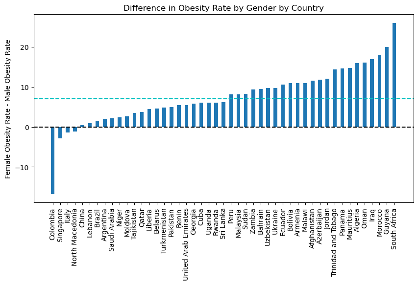

```python
# But, do countries with higher female obesity also have similarly high values of male adult obesity?
# Or does the difference between the vary much?

# Dataframe with country names and the gender obesity difference
country_gender = pd.DataFrame(data = {"Country":obesity_world_enricheddata['Country'],
                                     "Delta_Obesity": obesity_world_enricheddata['Females_Obesity'] - obesity_world_enricheddata['Males_Obesity']})

country_gender = country_gender.sort_values('Delta_Obesity').drop_duplicates('Country', keep='last').reset_index()
fig, ax = plt.subplots(figsize=(10, 5))

# Plot
ax.bar(country_gender["Country"], country_gender["Delta_Obesity"], width=0.5)
ax.set_ylabel('Female Obesity Rate - Male Obesity Rate')
ax.set_title('Difference in Obesity Rate by Gender by Country')
plt.axhline(y=0, color='k', linestyle='--')
plt.axhline(y=7, color='c', linestyle='--')
plt.xticks(rotation=90)
plt.show()
```

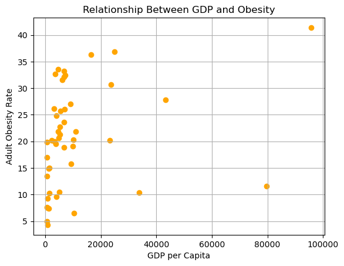

```python
# Obesity vs GDP per Capita

# Plot
plt.scatter(obesity_world_enricheddata['GDP_Per_Capita'], obesity_world_enricheddata['Adults_Obesity'], color='orange')
plt.xlabel("GDP per Capita")
plt.ylabel("Adult Obesity Rate")
plt.title("Relationship Between GDP and Obesity")
plt.grid(True)
plt.show()
```

Result: There is no clear link between GDP per capita and obesity rates. Both rich and poor countries can have high or low obesity. This means income alone doesn’t explain obesity—other factors like lifestyle and culture matter more.

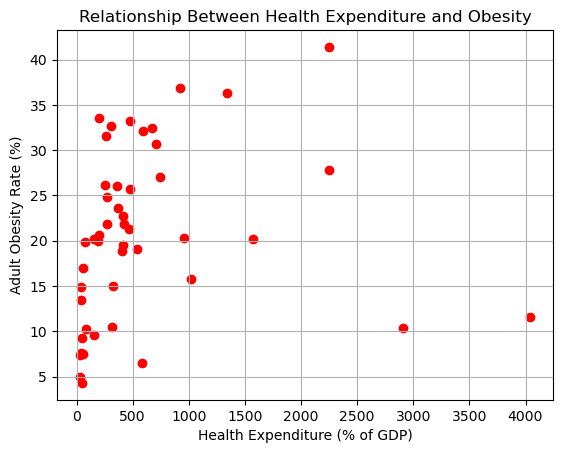

```python
# Health Expenditure vs Obesity

# Plot
plt.scatter(obesity_world_enricheddata['Health_Expenditure'], obesity_world_enricheddata['Adults_Obesity'], color='red')
plt.xlabel("Health Expenditure (% of GDP)")
plt.ylabel("Adult Obesity Rate (%)")
plt.title("Relationship Between Health Expenditure and Obesity")
plt.grid(True)
plt.show()
```

Result: The graph shows no clear relationship between health expenditure and adult obesity rates. Countries with both high and low spending on healthcare can still have high obesity levels.

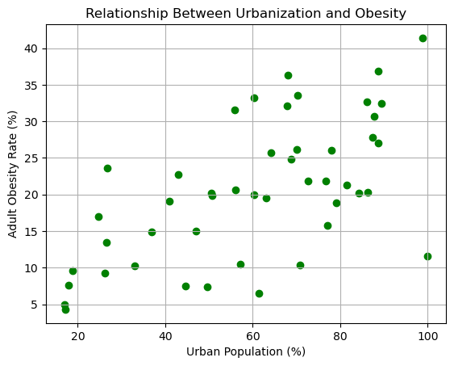

```python
# Urbanization vs Adult Obesity

# Plot
plt.scatter(obesity_world_enricheddata['Urban_Pop_Percent'],
            obesity_world_enricheddata['Adults_Obesity'],
            color='green')
plt.xlabel("Urban Population (%)")
plt.ylabel("Adult Obesity Rate (%)")
plt.title("Relationship Between Urbanization and Obesity")
plt.grid(True)
plt.show()
```

Result: The scatter plot shows a moderate upward trend, suggesting that countries with higher urban populations tend to have higher adult obesity rates.

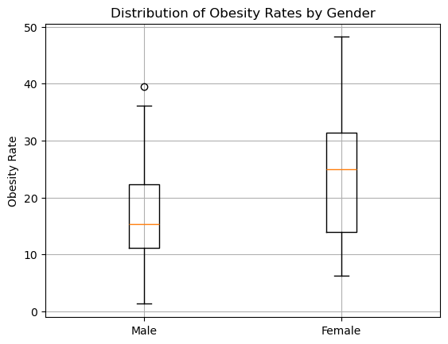

```python
# Obesity by Gender

# Plot
plt.boxplot([obesity_world_enricheddata['Males_Obesity'], obesity_world_enricheddata['Females_Obesity']],
            labels=['Male', 'Female'])
plt.ylabel("Obesity Rate")
plt.title("Distribution of Obesity Rates by Gender")
plt.grid(True)
plt.show()
```

Result: The boxplot shows that female obesity rates are generally higher and more variable than male obesity rates. The median obesity rate for females is higher, and the range is wider, with more extreme values. This indicates that obesity is more prevalent and more unevenly distributed among females across countries, highlighting the need for targeted interventions for women’s health.

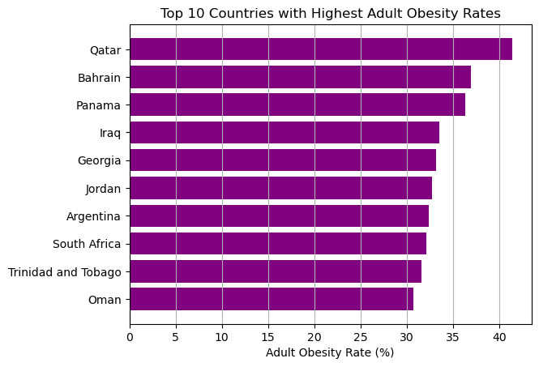

```python
# Top 10 countries with the highest adult obesity rates

# Sort the data
top10_obesity = obesity_world_enricheddata.sort_values(by='Adults_Obesity', ascending=False).head(10)

# Plot
plt.barh(top10_obesity['Country'], top10_obesity['Adults_Obesity'], color='purple')
plt.xlabel("Adult Obesity Rate (%)")
plt.title("Top 10 Countries with Highest Adult Obesity Rates")
plt.gca().invert_yaxis()
plt.grid(axis='x')
plt.show()
```

Result: The chart shows that Qatar, Bahrain, and Panama have the highest adult obesity rates, all exceeding 35%. The remaining countries including Iraq, Jordan, and South Africa, also show rates above 30%.

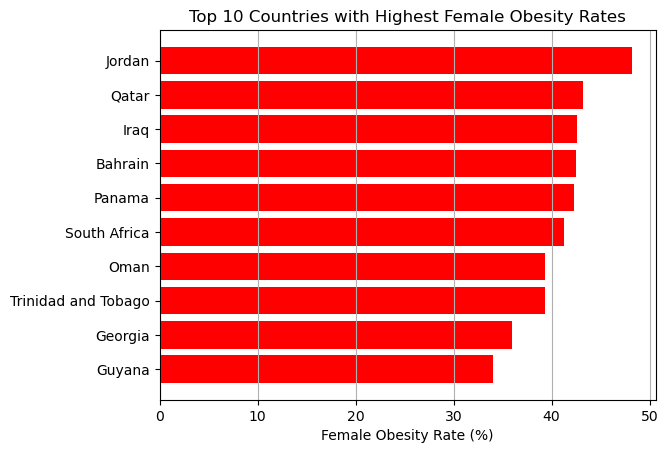

```python
# Top 10 Countries with Highest Female Obesity Rates

# Sort by Female Obesity in descending order and select the top 10
top10_female_obesity = obesity_world_enricheddata.sort_values(by='Females_Obesity', ascending=False).head(10)

# Create a horizontal bar chart
plt.barh(top10_female_obesity['Country'], top10_female_obesity['Females_Obesity'], color='red')
plt.xlabel("Female Obesity Rate (%)")
plt.title("Top 10 Countries with Highest Female Obesity Rates")
plt.gca().invert_yaxis()
plt.grid(axis='x')
plt.show()
```

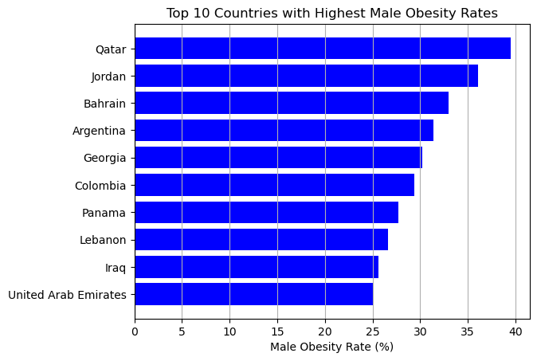

```python
# Top 10 Countries with Highest Male Obesity Rates

# Sort by Male Obesity in descending order and select the top 10
top10_male_obesity = obesity_world_enricheddata.sort_values(by='Males_Obesity', ascending=False).head(10)

# Plot
plt.barh(top10_male_obesity['Country'], top10_male_obesity['Males_Obesity'], color='blue')
plt.xlabel("Male Obesity Rate (%)")
plt.title("Top 10 Countries with Highest Male Obesity Rates")
plt.gca().invert_yaxis()
plt.grid(axis='x')
plt.show()
```

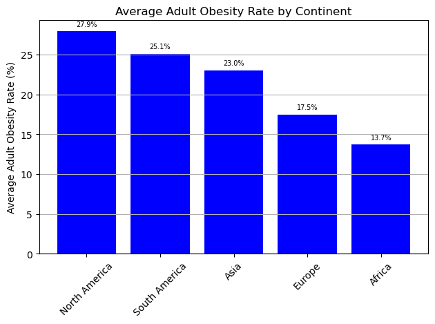

```python
continent_map = {
    'Algeria': 'Africa',
    'Argentina': 'South America',
    'Armenia': 'Asia',
    'Azerbaijan': 'Asia',
    'Bahrain': 'Asia',
    'Belarus': 'Europe',
    'Benin': 'Africa',
    'Bolivia': 'South America',
    'Brazil': 'South America',
    'China': 'Asia',
    'Colombia': 'South America',
    'Cuba': 'North America',
    'Ecuador': 'South America',
    'Georgia': 'Asia',
    'Guyana': 'South America',
    'Iraq': 'Asia',
    'Italy': 'Europe',
    'Jordan': 'Asia',
    'Lebanon': 'Asia',
    'Liberia': 'Africa',
    'Malawi': 'Africa',
    'Malaysia': 'Asia',
    'Mauritius': 'Africa',
    'Moldova': 'Europe',
    'Morocco': 'Africa',
    'Niger': 'Africa',
    'North Macedonia': 'Europe',
    'Oman': 'Asia',
    'Pakistan': 'Asia',
    'Panama': 'North America',
    'Peru': 'South America',
    'Qatar': 'Asia',
    'Rwanda': 'Africa',
    'Saudi Arabia': 'Asia',
    'Singapore': 'Asia',
    'South Africa': 'Africa',
    'Sri Lanka': 'Asia',
    'Sudan': 'Africa',
    'Tajikistan': 'Asia',
    'Trinidad and Tobago': 'North America',
    'Turkmenistan': 'Asia',
    'Uganda': 'Africa',
    'Ukraine': 'Europe',
    'United Arab Emirates': 'Asia',
    'Uzbekistan': 'Asia',
    'Zambia': 'Africa'
}
# Add 'Continent' column to the DataFrame
obesity_world_enricheddata['Continent'] = obesity_world_enricheddata['Country'].map(continent_map)

# Compute average adult obesity rate by continent
continent_avg_obesity = obesity_world_enricheddata.groupby('Continent')['Adults_Obesity'].mean().sort_values(ascending=False)

# Plot
fig, ax = plt.subplots()
bars = ax.bar(continent_avg_obesity.index, continent_avg_obesity.values, color='blue')

for bar in bars:
    height = bar.get_height()
    ax.text(bar.get_x() + bar.get_width()/2, height + 0.5, f'{height:.1f}%',
            ha='center', va='bottom', fontsize=7)

# Result
ax.set_ylabel("Average Adult Obesity Rate (%)")
ax.set_title("Average Adult Obesity Rate by Continent")
plt.xticks(rotation=45)
plt.grid(axis='y')
plt.tight_layout()
plt.show()
```

Result: The chart shows that North America has the highest average adult obesity rate at 27.9%, followed by South America (25.1%) and Asia (23.0%). In contrast, Europe and Africa have significantly lower averages, at 17.5% and 13.7% respectively.

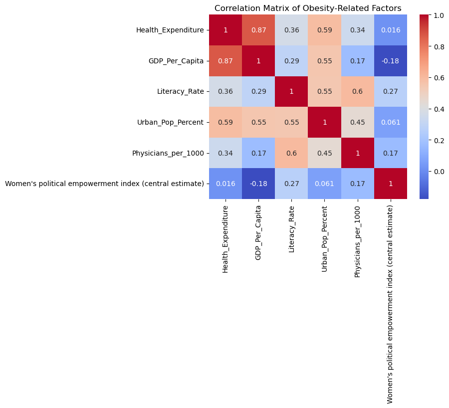

```python
obesity_world_enricheddata = obesity_world_enricheddata.drop(columns=['Continent'])

# Correlation Heatmap
correlation_data = obesity_world_enricheddata[['Health_Expenditure', 'GDP_Per_Capita', 'Literacy_Rate',
                                               'Urban_Pop_Percent', 'Physicians_per_1000',
                                                "Women's political empowerment index (central estimate)"]]
sns.heatmap(correlation_data.corr(), annot=True, cmap='coolwarm')
plt.title("Correlation Matrix of Obesity-Related Factors")
plt.show()
```

Result: The correlation matrix reveals that Health Expenditure and GDP per Capita are strongly positively correlated (0.87), indicating that wealthier countries tend to spend more on healthcare. Urban Population Percentage, Literacy Rate, and Number of Physicians show moderate positive correlations with each other, suggesting that more urbanized and educated societies have better healthcare access. In contrast, the Women's Political Empowerment Index has weak or negative correlations with most other variables, indicating that political empowerment may not be directly tied to economic or healthcare factors in this dataset.

# 3. Support Vector Machine

## 3.1 Create Target Variable "Obesity"

```python
# Create binary target variable based on median Adults_Obesity
median_obesity = obesity_world_enricheddata['Adults_Obesity'].median()

obesity_world_enricheddata['Obesity'] = (
    obesity_world_enricheddata['Adults_Obesity'] > median_obesity
).astype(int)

# Remove specified obesity-related features
features_to_remove = [
    'Males_Overweight', 'Males_Obesity',
    'Females_Overweight', 'Females_Obesity',
    'Adults_Overweight', 'Adults_Obesity'
]
obesity_world_enricheddata.drop(columns=features_to_remove, inplace=True, errors='ignore')

# Define modeling features
features = [
    'Health_Expenditure',
    'GDP_Per_Capita',
    'Literacy_Rate',
    'Physicians_per_1000',
    'Urban_Pop_Percent',
    "Women's political empowerment index (central estimate)"
]

# Create feature matrix and target vector from the correct DataFrame
X = obesity_world_enricheddata[features]
y = obesity_world_enricheddata['Obesity']

# Results
print("Shape of feature matrix X:", X.shape)
print("Shape of target vector y:", y.shape)
obesity_world_enricheddata.info()
obesity_world_enricheddata.head()
```

```
Shape of feature matrix X: (47, 6)
Shape of target vector y: (47,)
<class 'pandas.core.frame.DataFrame'>
RangeIndex: 47 entries, 0 to 46
Data columns (total 9 columns):
 #   Column                                                  Non-Null Count  Dtype
---  ------                                                  --------------  -----
 0   Country                                                 47 non-null     object
 1   Year                                                    47 non-null     int32
 2   Health_Expenditure                                      47 non-null     float64
 3   GDP_Per_Capita                                          47 non-null     float64
 4   Literacy_Rate                                           47 non-null     float64
 5   Physicians_per_1000                                     47 non-null     float64
 6   Urban_Pop_Percent                                       47 non-null     float64
 7   Women's political empowerment index (central estimate)  47 non-null     float64
 8   Obesity                                                 47 non-null     int32
dtypes: float64(6), int32(2), object(1)
memory usage: 3.1+ KB
```

|  | Country | Year | Health_Expenditure | GDP_Per_Capita | Literacy_Rate | Physicians_per_1000 | Urban_Pop_Percent | Women's political empowerment index (central estimate) | Obesity |
| --- | --- | --- | --- | --- | --- | --- | --- | --- | --- |
| 0 | Afghanistan | 2018 | 59.919605 | 565.569730 | 33.753841 | 0.2910 | 24.803 | 0.045 | 0 |
| 1 | Algeria | 2016 | 271.537781 | 4577.210292 | 81.407837 | 1.7320 | 72.629 | 0.636 | 1 |
| 2 | Argentina | 2018 | 668.793091 | 7141.475077 | 97.000000 | 3.2481 | 89.329 | 0.849 | 1 |
| 3 | Armenia | 2016 | 409.801453 | 3869.053739 | 100.000000 | 2.9720 | 63.103 | 0.892 | 0 |
| 4 | Azerbaijan | 2017 | 199.257462 | 4805.753718 | 100.000000 | 3.1110 | 56.031 | 0.621 | 1 |

# 3.2 Class Balance

```python
# Class Balance
print("\nClass Class Balance (Obesity):")
print(obesity_world_enricheddata['Obesity'].value_counts())

# Class Balance with Percentages
print("\nClass Class Balance with Percentages:")
print(obesity_world_enricheddata['Obesity'].value_counts(normalize=True) * 100)
```

```
Class Class Balance (Obesity):
Obesity
0    24
1    23
Name: count, dtype: int64

Class Class Balance with Percentages:
Obesity
0    51.06383
1    48.93617
Name: proportion, dtype: float64
```

Result: The target class "Obesity" is well-balanced, with 24 non-obese 51% and 23 obese 49% countries. This near-even distribution makes the dataset suitable for training reliable classification models without the need for major resampling.

# 3.3 Support Vector Machine Models

# 3.3.1 Tuned Linear SVM

```python
# Split into training and test sets
X_train, X_test, y_train, y_test = train_test_split(
    X, y, test_size=0.3, stratify=y, random_state=42
)

# Scale the features
scaler = StandardScaler()
X_train_scaled = scaler.fit_transform(X_train)
X_test_scaled = scaler.transform(X_test)

# Tuned Linear SVM
tuned_linear_svm = SVC(kernel='linear', random_state=42)
param_grid = {'C': [0.01, 0.1, 1, 10, 100]}

# Grid search
grid_search = GridSearchCV(estimator=tuned_linear_svm, param_grid=param_grid, cv=5, scoring='accuracy')
grid_search.fit(X_train_scaled, y_train)

# Best model
best_tuned_linear_svm = grid_search.best_estimator_

# Predict
y_pred = best_tuned_linear_svm.predict(X_test_scaled)


# Training and Test Error
train_accuracy_tuned_linear = best_tuned_linear_svm.score(X_train_scaled, y_train)
test_accuracy_tuned_linear = best_tuned_linear_svm.score(X_test_scaled, y_test)
train_error_tuned_linear = 1 - train_accuracy_tuned_linear
test_error_tuned_linear = 1 - test_accuracy_tuned_linear

# Confusion matrix as labeled DataFrame
conf_matrix_tuned_linear = confusion_matrix(y_test, y_pred)
conf_df = pd.DataFrame(conf_matrix_tuned_linear,
                       index=['Actual: 0', 'Actual: 1'],
                       columns=['Predicted: 0', 'Predicted: 1'])

# Results
print("Best Parameters (Tuned Linear SVM) C value:", grid_search.best_params_['C'])
print(f"Training Accuracy: {train_accuracy_tuned_linear:.4f}")
print(f"Training Error: {train_error_tuned_linear:.4f}")
print(f"Test Accuracy: {test_accuracy_tuned_linear:.4f}")
print(f"Test Error: {test_error_tuned_linear:.4f}")
print("\nConfusion Matrix:\n", conf_df)
print("\nClassification Report:\n", classification_report(y_test, y_pred))
```

```
Best Parameters (Tuned Linear SVM) C value: 10
Training Accuracy: 0.9062
Training Error: 0.0938
Test Accuracy: 0.6000
Test Error: 0.4000

Confusion Matrix:
            Predicted: 0  Predicted: 1
Actual: 0             6             2
Actual: 1             4             3

Classification Report:
               precision    recall  f1-score   support

           0       0.60      0.75      0.67         8
           1       0.60      0.43      0.50         7

    accuracy                           0.60        15
   macro avg       0.60      0.59      0.58        15
weighted avg       0.60      0.60      0.59        15
```

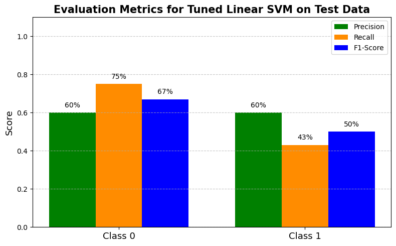

```python
# Evaluation Metrics for Tuned Linear SVM on Test Data
classes = ['Class 0', 'Class 1']
precision = [0.60, 0.60]
recall = [0.75, 0.43]
f1_score = [0.67, 0.50]

x = np.arange(len(classes))
bar_width = 0.25

fig, ax = plt.subplots(figsize=(8, 5))

# Plotting the bars
bars1 = ax.bar(x - bar_width, precision, width=bar_width, label='Precision', color='green')
bars2 = ax.bar(x, recall, width=bar_width, label='Recall', color='darkorange')
bars3 = ax.bar(x + bar_width, f1_score, width=bar_width, label='F1-Score', color='blue')

# Annotate the bars with percentages
for bars in [bars1, bars2, bars3]:
    for bar in bars:
        height = bar.get_height()
        ax.text(bar.get_x() + bar.get_width() / 2, height + 0.02,
                f'{height * 100:.0f}%', ha='center', va='bottom', fontsize=10)

# Formatting
ax.set_ylabel('Score', fontsize=13)
ax.set_title('Evaluation Metrics for Tuned Linear SVM on Test Data', fontsize=15, fontweight='bold')
ax.set_xticks(x)
ax.set_xticklabels(classes, fontsize=13)
ax.set_ylim(0, 1.1)
ax.legend(fontsize=10)
ax.grid(axis='y', linestyle='--', alpha=0.7)

plt.tight_layout()
plt.show()
```

Result: The tuned Linear SVM with C = 10 achieved a high training accuracy of 90.6% but a significantly lower test accuracy of 60.0%, suggesting the model is likely overfitting the training data. The confusion matrix shows that the model predicts class 0 (non-obesity) better than class 1 (obesity), with a recall of 75% for class 0 but only 43% for class 1.

# 3.3.2 Tuned Radial SVM

```python
# Tuned Radial SVM
tuned_radial_svm = SVC(kernel='rbf', random_state=42)
param_grid_radial = {
    'C': [0.01, 0.1, 1, 10, 100],
    'gamma': [0.001, 0.01, 0.1, 1]
}

grid_search_radial = GridSearchCV(tuned_radial_svm, param_grid_radial, cv=5, scoring='accuracy')
grid_search_radial.fit(X_train_scaled, y_train)

# Best model
best_tuned_radial_svm = grid_search_radial.best_estimator_
y_pred_tuned_radial = best_tuned_radial_svm.predict(X_test_scaled)

# Training and Test Error
train_accuracy_tuned_radial = best_tuned_radial_svm.score(X_train_scaled, y_train)
test_accuracy_tuned_radial = best_tuned_radial_svm.score(X_test_scaled, y_test)
train_error_tuned_radial = 1 - train_accuracy_tuned_radial
test_error_tuned_radial = 1 - test_accuracy_tuned_radial

# Confusion Matrix as DataFrame
conf_matrix_tuned_radial = confusion_matrix(y_test, y_pred_tuned_radial)
conf_df_tuned_radial = pd.DataFrame(conf_matrix_tuned_radial,
                           index=['Actual: 0', 'Actual: 1'],
                           columns=['Predicted: 0', 'Predicted: 1'])

# Results
print("Best Parameters (Tuned Radial SVM):", grid_search_radial.best_params_)
print(f"Training Accuracy: {train_accuracy_tuned_radial:.4f}")
print(f"Training Error: {train_error_tuned_radial:.4f}")
print(f"Test Accuracy: {test_accuracy_tuned_radial:.4f}")
print(f"Test Error: {test_error_tuned_radial:.4f}")
print("\n Confusion Matrix:\n", conf_df_tuned_radial)
print("\n Classification Report:\n", classification_report(y_test, y_pred_tuned_radial))
```

```
Best Parameters (Tuned Radial SVM): {'C': 1, 'gamma': 1}
Training Accuracy: 0.9688
Training Error: 0.0312
Test Accuracy: 0.6000
Test Error: 0.4000

 Confusion Matrix:
            Predicted: 0  Predicted: 1
Actual: 0             7             1
Actual: 1             5             2

 Classification Report:
               precision    recall  f1-score   support

           0       0.58      0.88      0.70         8
           1       0.67      0.29      0.40         7

    accuracy                           0.60        15
   macro avg       0.62      0.58      0.55        15
weighted avg       0.62      0.60      0.56        15
```

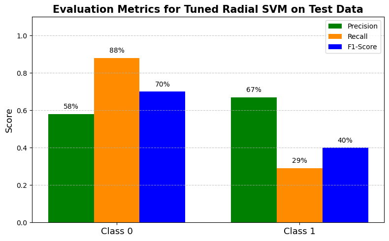

```python
# Evaluation Metrics for Tuned Radial SVM on Test Data
classes = ['Class 0', 'Class 1']
precision = [0.58, 0.67]
recall = [0.88, 0.29]
f1_score = [0.70, 0.40]

x = np.arange(len(classes))
bar_width = 0.25

fig, ax = plt.subplots(figsize=(8, 5))

# Plotting the bars
bars1 = ax.bar(x - bar_width, precision, width=bar_width, label='Precision', color='green')
bars2 = ax.bar(x, recall, width=bar_width, label='Recall', color='darkorange')
bars3 = ax.bar(x + bar_width, f1_score, width=bar_width, label='F1-Score', color='blue')

# Annotate the bars with percentages
for bars in [bars1, bars2, bars3]:
    for bar in bars:
        height = bar.get_height()
        ax.text(bar.get_x() + bar.get_width() / 2, height + 0.02,
                f'{height * 100:.0f}%', ha='center', va='bottom', fontsize=10)

# Formatting
ax.set_ylabel('Score', fontsize=13)
ax.set_title('Evaluation Metrics for Tuned Radial SVM on Test Data', fontsize=15, fontweight='bold')
ax.set_xticks(x)
ax.set_xticklabels(classes, fontsize=13)
ax.set_ylim(0, 1.1)
ax.legend(fontsize=10)
ax.grid(axis='y', linestyle='--', alpha=0.7)

plt.tight_layout()
plt.show()
```

Result: The tuned Radial SVM (with C = 1, gamma = 1) achieved excellent training accuracy of 96.9%, but its test accuracy dropped to 60%, indicating overfitting. The confusion matrix shows that the model performs well on class 0 (non-obesity), with 88% recall, but struggles to correctly classify class 1 (obesity), achieving only 29% recall. Although precision is relatively balanced, the macro average F1-score is low 55%.

# 3.3.3 Tuned Polynomial SVM

```python
# Tuned Polynomial SVM
tuned_poly_svm = SVC(kernel='poly', random_state=42)
param_grid_poly = {
    'C': [0.01, 0.1, 1, 10],
    'degree': [2, 3, 4],
    'gamma': ['scale', 'auto']
}

# Grid Search CV
grid_search_tuned_poly = GridSearchCV(tuned_poly_svm, param_grid_poly, cv=5, scoring='accuracy')
grid_search_tuned_poly.fit(X_train_scaled, y_train)

# Best model
best_tuned_poly_svm = grid_search_tuned_poly.best_estimator_
y_pred_tuned_poly = best_tuned_poly_svm.predict(X_test_scaled)

# Training and Test Error
train_accuracy_tuned_poly = best_tuned_poly_svm.score(X_train_scaled, y_train)
test_accuracy_tuned_poly = best_tuned_poly_svm.score(X_test_scaled, y_test)
train_error_tuned_poly = 1 - train_accuracy_tuned_poly
test_error_tuned_poly = 1 - test_accuracy_tuned_poly

# Confusion matrix
conf_matrix_tuned_poly = confusion_matrix(y_test, y_pred_tuned_poly)
conf_df_tuned_poly = pd.DataFrame(conf_matrix_tuned_poly,
                            index=['Actual: 0', 'Actual: 1'],
                            columns=['Predicted: 0', 'Predicted: 1'])

# Results
print("Best Parameters (Tuned Polynomial SVM):", grid_search_tuned_poly.best_params_)
print(f"Training Accuracy: {train_accuracy_tuned_poly:.4f}")
print(f"Training Error: {train_error_tuned_poly:.4f}")
print(f"Test Accuracy: {test_accuracy_tuned_poly:.4f}")
print(f"Test Error: {test_error_tuned_poly:.4f}")
print("\nConfusion Matrix:\n", conf_df_tuned_poly)
print("\nClassification Report:\n", classification_report(y_test, y_pred_tuned_poly))
```

```
Best Parameters (Tuned Polynomial SVM): {'C': 1, 'degree': 2, 'gamma': 'scale'}
Training Accuracy: 0.7812
Training Error: 0.2188
Test Accuracy: 0.6000
Test Error: 0.4000

Confusion Matrix:
            Predicted: 0  Predicted: 1
Actual: 0             3             5
Actual: 1             1             6

Classification Report:
               precision    recall  f1-score   support

           0       0.75      0.38      0.50         8
           1       0.55      0.86      0.67         7

    accuracy                           0.60        15
   macro avg       0.65      0.62      0.58        15
weighted avg       0.65      0.60      0.58        15
```

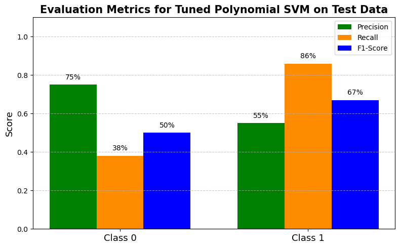

```python
# Evaluation Metrics for Tuned Polynomial SVM on Test Data
classes = ['Class 0', 'Class 1']
precision = [0.75, 0.55]
recall = [0.38, 0.86]
f1_score = [0.50, 0.67]

x = np.arange(len(classes))
bar_width = 0.25

fig, ax = plt.subplots(figsize=(8, 5))

# Plotting the bars
bars1 = ax.bar(x - bar_width, precision, width=bar_width, label='Precision', color='green')
bars2 = ax.bar(x, recall, width=bar_width, label='Recall', color='darkorange')
bars3 = ax.bar(x + bar_width, f1_score, width=bar_width, label='F1-Score', color='blue')

# Annotate the bars with percentages
for bars in [bars1, bars2, bars3]:
    for bar in bars:
        height = bar.get_height()
        ax.text(bar.get_x() + bar.get_width() / 2, height + 0.02,
                f'{height * 100:.0f}%', ha='center', va='bottom', fontsize=10)

# Formatting
ax.set_ylabel('Score', fontsize=13)
ax.set_title('Evaluation Metrics for Tuned Polynomial SVM on Test Data', fontsize=15, fontweight='bold')
ax.set_xticks(x)
ax.set_xticklabels(classes, fontsize=13)
ax.set_ylim(0, 1.1)
ax.legend(fontsize=10)
ax.grid(axis='y', linestyle='--', alpha=0.7)

plt.tight_layout()
plt.show()
```

Result: The tuned Polynomial SVM (with C=1, degree=2, gamma='scale') achieved moderate training accuracy of 78.1% and test accuracy of 60.0%, indicating the model has reasonable generalization with less overfitting than the Radial SVM. The confusion matrix shows that the model predicts class 1 (obesity) much better than class 0 (non-obesity), with a recall of 86% for class 1 but only 38% for class 0.

# 3.3.4 Performance Comparison of Tuned Linear, Radial, and Polynomial Models

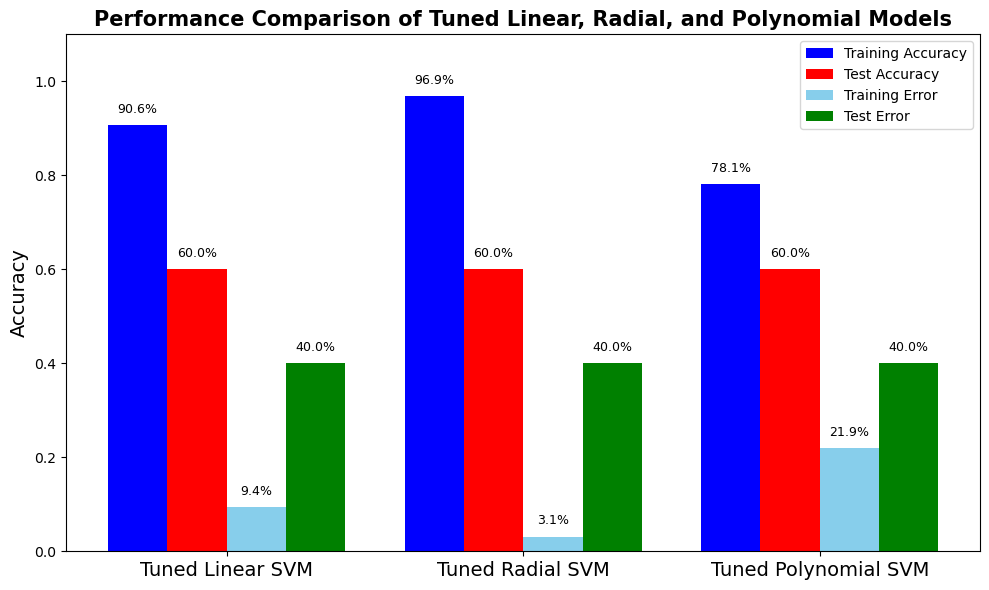

```python
# Training/Test Accuracy and Error by SVM Models

# Model Names
models = ['Tuned Linear SVM', 'Tuned Radial SVM', 'Tuned Polynomial SVM']

# Accuracy and Error
train_accuracy = [train_accuracy_tuned_linear, train_accuracy_tuned_radial, train_accuracy_tuned_poly]
test_accuracy = [test_accuracy_tuned_linear, test_accuracy_tuned_radial, test_accuracy_tuned_poly]
train_error = [train_error_tuned_linear, train_error_tuned_radial, train_error_tuned_poly]
test_error = [test_error_tuned_linear, test_error_tuned_radial, test_error_tuned_poly]

# Bar position
x = np.arange(len(models))
width = 0.2

# Plot
fig, ax = plt.subplots(figsize=(10, 6))

# Plot bars
bars1 = ax.bar(x - 1.5*width, train_accuracy, width, label='Training Accuracy', color='blue')
bars2 = ax.bar(x - 0.5*width, test_accuracy, width, label='Test Accuracy', color='red')
bars3 = ax.bar(x + 0.5*width, train_error, width, label='Training Error', color='skyblue')
bars4 = ax.bar(x + 1.5*width, test_error, width, label='Test Error', color='green')

# Labels and formatting
ax.set_ylabel('Accuracy', fontsize=14)
ax.set_title('Performance Comparison of Tuned Linear, Radial, and Polynomial Models', fontsize=15, fontweight='bold')
ax.set_xticks(x)
ax.set_xticklabels(models, fontsize=14)
ax.set_ylim(0, 1.1)
ax.legend(fontsize=10)

# Annotate bars
for bars in [bars1, bars2, bars3, bars4]:
    for bar in bars:
        height = bar.get_height()
        ax.text(bar.get_x() + bar.get_width()/2, height + 0.02,
                f'{height * 100:.1f}%', ha='center', va='bottom', fontsize=9)

plt.tight_layout()
plt.show()
```

```
Tuned Polynomial SVM (C=1, degree=2, gamma='scale')

Training Accuracy: 0.7188
Training Error: 0.2812
Test Accuracy: 0.6000
Test Error: 0.4000

Confusion Matrix:
           Predicted: 0  Predicted: 1
Actual: 0             2             6
Actual: 1             0             7

Classification Report:
               precision    recall  f1-score   support

           0       1.00      0.25      0.40         8
           1       0.54      1.00      0.70         7

    accuracy                           0.60        15
   macro avg       0.77      0.62      0.55        15
weighted avg       0.78      0.60      0.54        15
```

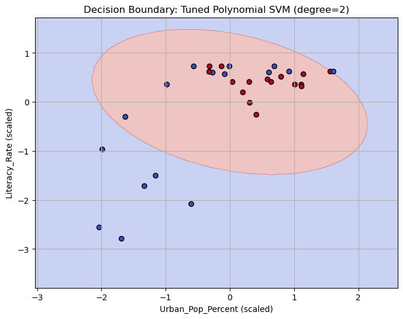

```python
# Polynomial SVM with Decision Boundary Visualization

# 2 features and target
features_2top = ['Urban_Pop_Percent', 'Literacy_Rate']
X = obesity_world_enricheddata[features_2top]
y = obesity_world_enricheddata['Obesity']

# Train-test split
X_train, X_test, y_train, y_test = train_test_split(
    X, y, test_size=0.3, stratify=y, random_state=42
)

# Scale features
scaler = StandardScaler()
X_train_scaled = scaler.fit_transform(X_train)
X_test_scaled = scaler.transform(X_test)

# Tuned Polynomial SVM
poly_svm = SVC(kernel='poly', C=1, degree=2, gamma='scale', random_state=42)
poly_svm.fit(X_train_scaled, y_train)

# Predict
y_pred = poly_svm.predict(X_test_scaled)

# Training and Test Error
train_acc = poly_svm.score(X_train_scaled, y_train)
test_acc = poly_svm.score(X_test_scaled, y_test)
train_err = 1 - train_acc
test_err = 1 - test_acc

# Results
print("Tuned Polynomial SVM (C=1, degree=2, gamma='scale')\n")
print(f"Training Accuracy: {train_acc:.4f}")
print(f"Training Error: {train_err:.4f}")
print(f"Test Accuracy: {test_acc:.4f}")
print(f"Test Error: {test_err:.4f}")
print("\nConfusion Matrix:")
print(pd.DataFrame(confusion_matrix(y_test, y_pred),
                   index=['Actual: 0', 'Actual: 1'],
                   columns=['Predicted: 0', 'Predicted: 1']))
print("\nClassification Report:\n", classification_report(y_test, y_pred))

# Plot decision boundary
x_min, x_max = X_train_scaled[:, 0].min() - 1, X_train_scaled[:, 0].max() + 1
y_min, y_max = X_train_scaled[:, 1].min() - 1, X_train_scaled[:, 1].max() + 1
xx, yy = np.meshgrid(np.linspace(x_min, x_max, 500),
                     np.linspace(y_min, y_max, 500))

Z = poly_svm.predict(np.c_[xx.ravel(), yy.ravel()])
Z = Z.reshape(xx.shape)

plt.figure(figsize=(8, 6))
plt.contourf(xx, yy, Z, alpha=0.3, cmap='coolwarm')
plt.scatter(X_train_scaled[:, 0], X_train_scaled[:, 1], c=y_train, edgecolors='k', cmap='coolwarm')
plt.xlabel('Urban_Pop_Percent (scaled)')
plt.ylabel('Literacy_Rate (scaled)')
plt.title('Decision Boundary: Tuned Polynomial SVM (degree=2)')
plt.grid(True)
plt.show()
```

Result: The tuned Polynomial SVM (C=1, degree=2, gamma='scale') achieved a training accuracy of 71.9% and test accuracy of 60.0%, showing a moderate generalization ability with reduced overfitting compared to previous models. The confusion matrix reveals strong performance in predicting obesity cases (class 1), with a perfect recall of 100% and F1-score of 70%, but a low recall for non-obesity individuals 25%, indicating a bias toward predicting obesity. The decision boundary plot, using Urban_Pop_Percent and Literacy_Rate, shows a nonlinear curved separation, with clear regions but significant overlap. Most class 1 (obesity) points fall correctly into the red region, while many class 0 (non-obesity) points are misclassified.

## 3.3.5 Soft Voting SVM Ensemble on Three Subsets

```python
# Create Three Subset
subset1_economic = ['Health_Expenditure', 'GDP_Per_Capita', 'Physicians_per_1000']
subset2_society = ['Literacy_Rate', 'Urban_Pop_Percent']
subset3_political = ["Women's political empowerment index (central estimate)"]

# Target
y = obesity_world_enricheddata['Obesity']

# Train and tuned SVM Voting for a subset
def train_svm_voting(X, y):
    # Split Data
    X_train, X_test, y_train, y_test = train_test_split(X, y, test_size=0.3, stratify=y, random_state=42)

    # Scale
    scaler = StandardScaler().fit(X_train)
    X_train_scaled = scaler.transform(X_train)
    X_test_scaled = scaler.transform(X_test)

    # Tuned Linear SVM
    linear_svm = SVC(kernel='linear', probability=True, random_state=42)
    param_grid_linear = {'C': [0.1, 1, 10, 100]}
    grid_linear = GridSearchCV(linear_svm, param_grid_linear, cv=5, scoring='accuracy', n_jobs=-1)
    grid_linear.fit(X_train_scaled, y_train)
    best_linear = grid_linear.best_estimator_

    # Tuned Radial SVM
    radial_svm = SVC(kernel='rbf', probability=True, random_state=42)
    param_grid_radial = {'C': [0.1, 1, 10, 100], 'gamma': ['scale', 0.01, 0.1, 1]}
    grid_radial = GridSearchCV(radial_svm, param_grid_radial, cv=5, scoring='accuracy', n_jobs=-1)
    grid_radial.fit(X_train_scaled, y_train)
    best_radial = grid_radial.best_estimator_

    # Tuned Polynomial SVM
    poly_svm = SVC(kernel='poly', probability=True, random_state=42)
    param_grid_poly = {'C': [0.1, 1, 10], 'gamma': ['scale', 0.01, 0.1], 'degree': [2, 3, 4]}
    grid_poly = GridSearchCV(poly_svm, param_grid_poly, cv=5, scoring='accuracy', n_jobs=-1)
    grid_poly.fit(X_train_scaled, y_train)
    best_poly = grid_poly.best_estimator_

    # Voting Classifier
    voting_svm = VotingClassifier(
        estimators=[
            ('linear_svm', best_linear),
            ('radial_svm', best_radial),
            ('poly_svm', best_poly)
        ],
        voting='soft'
    )

    # Train Voting Tuned SVM
    voting_svm.fit(X_train_scaled, y_train)

    # Train and Test Prediction
    y_train_pred = voting_svm.predict(X_train_scaled)
    y_test_pred = voting_svm.predict(X_test_scaled)

    # Accuracy
    train_accuracy = accuracy_score(y_train, y_train_pred)
    test_accuracy = accuracy_score(y_test, y_test_pred)

    # Error
    train_error = 1 - train_accuracy
    test_error = 1 - test_accuracy

    # Print Results
    print(f"\nTraining Accuracy: {train_accuracy:.4f}")
    print(f"Training Error: {train_error:.4f}")
    print(f"Testing Accuracy: {test_accuracy:.4f}")
    print(f"Testing Error: {test_error:.4f}")

    # Test Evaluation
    print("\nClassification Report:\n", classification_report(y_test, y_test_pred))
    print("Confusion Matrix:\n")
    print(pd.DataFrame(confusion_matrix(y_test, y_test_pred),
                       index=['Actual: 0', 'Actual: 1'],
                       columns=['Predicted: 0', 'Predicted: 1']))

# Train for Subset 1: Economic and Health Features
print("\nSubset 1: Economic and Health Subset")
X1 = obesity_world_enricheddata[subset1_economic]
train_svm_voting(X1, y)

# Train for Subset 2: Society Features
print("\nSubset 2: Society Subset")
X2 = obesity_world_enricheddata[subset2_society]
train_svm_voting(X2, y)

# Train for Subset 3: Political Features
print("\nSubset 3: Political Subset")
X3 = obesity_world_enricheddata[subset3_political]
train_svm_voting(X3, y)
```

```
Subset 1: Economic and Health Subset

Training Accuracy: 0.5000
Training Error: 0.5000
Testing Accuracy: 0.4667
Testing Error: 0.5333

Classification Report:
               precision    recall  f1-score   support

           0       0.50      0.12      0.20         8
           1       0.46      0.86      0.60         7

    accuracy                           0.47        15
   macro avg       0.48      0.49      0.40        15
weighted avg       0.48      0.47      0.39        15

Confusion Matrix:

           Predicted: 0  Predicted: 1
Actual: 0             1             7
Actual: 1             1             6

Subset 2: Society Subset

Training Accuracy: 0.7500
Training Error: 0.2500
Testing Accuracy: 0.7333
Testing Error: 0.2667

Classification Report:
               precision    recall  f1-score   support

           0       0.75      0.75      0.75         8
           1       0.71      0.71      0.71         7

    accuracy                           0.73        15
   macro avg       0.73      0.73      0.73        15
weighted avg       0.73      0.73      0.73        15

```

[output cut: 13 more lines]

```
Classification Report:
               precision    recall  f1-score   support

           0       0.53      1.00      0.70         8
           1       0.00      0.00      0.00         7

    accuracy                           0.53        15
   macro avg       0.27      0.50      0.35        15
weighted avg       0.28      0.53      0.37        15

Confusion Matrix:

           Predicted: 0  Predicted: 1
Actual: 0             8             0
Actual: 1             7             0
```

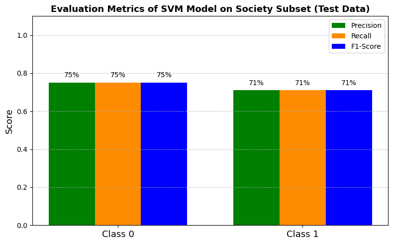

```python
# Evaluation Metrics of SVM Model on Society Feature Subset (Test Data)
classes = ['Class 0', 'Class 1']
precision = [0.75, 0.71]
recall = [0.75, 0.71]
f1_score = [0.75, 0.71]

x = np.arange(len(classes))
bar_width = 0.25

fig, ax = plt.subplots(figsize=(8, 5))

# Plotting the bars
bars1 = ax.bar(x - bar_width, precision, width=bar_width, label='Precision', color='green')
bars2 = ax.bar(x, recall, width=bar_width, label='Recall', color='darkorange')
bars3 = ax.bar(x + bar_width, f1_score, width=bar_width, label='F1-Score', color='blue')

# Annotate the bars with percentages
for bars in [bars1, bars2, bars3]:
    for bar in bars:
        height = bar.get_height()
        ax.text(bar.get_x() + bar.get_width() / 2, height + 0.02,
                f'{height * 100:.0f}%', ha='center', va='bottom', fontsize=10)

# Formatting
ax.set_ylabel('Score', fontsize=13)
ax.set_title('Evaluation Metrics of SVM Model on Society Subset (Test Data)', fontsize=13, fontweight='bold')
ax.set_xticks(x)
ax.set_xticklabels(classes, fontsize=13)
ax.set_ylim(0, 1.1)
ax.legend(fontsize=10)
ax.grid(axis='y', linestyle='--', alpha=0.7)

plt.tight_layout()
plt.show()
```

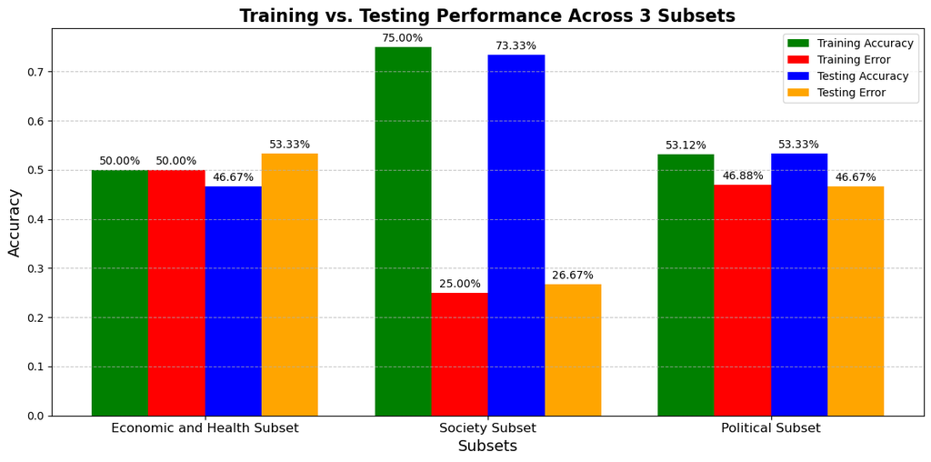

```python
# Results
subsets_sets = ['Economic and Health Subset', 'Society Subset', 'Political Subset']
training_accuracy = [0.5000, 0.7500, 0.5312]
training_error = [0.5000, 0.2500, 0.4688]
testing_accuracy = [0.4667, 0.7333, 0.5333]
testing_error = [0.5333, 0.2667, 0.4667]

# Set position of bar on X axis
x = np.arange(len(subsets_sets))
width = 0.2

# Bar plots
fig, ax = plt.subplots(figsize=(12, 6))

bars1 = ax.bar(x - 1.5*width, training_accuracy, width, label='Training Accuracy', color='green')
bars2 = ax.bar(x - 0.5*width, training_error, width, label='Training Error', color='red')
bars3 = ax.bar(x + 0.5*width, testing_accuracy, width, label='Testing Accuracy', color='blue')
bars4 = ax.bar(x + 1.5*width, testing_error, width, label='Testing Error', color='orange')

ax.set_xlabel('Subsets', fontsize=14)
ax.set_ylabel('Accuracy', fontsize=14)
ax.set_title('Training vs. Testing Performance Across 3 Subsets', fontsize=16, weight='bold')
ax.set_xticks(x)
ax.set_xticklabels(subsets_sets, fontsize=12)
ax.legend(fontsize=10)

# Add grid
ax.grid(axis='y', linestyle='--', alpha=0.7)

# Add labels as percentages
def add_labels(bars):
    for bar in bars:
        height = bar.get_height()
        ax.annotate(f'{height*100:.2f}%',
                    xy=(bar.get_x() + bar.get_width() / 2, height),
                    xytext=(0, 3),
                    textcoords="offset points",
                    ha='center', va='bottom', fontsize=10)

add_labels(bars1)
add_labels(bars2)
add_labels(bars3)
add_labels(bars4)
plt.tight_layout()
plt.show()
```

Result: Society subset (Urban_Pop_Percent and Literacy Rate) achieved the highest training accuracy of 75% and highest testing accuracy of 73.3%. Also had the lowest training and testing errors, indicating strong generalization. This is the best-performing subset, showing that societal factors are most predictive of obesity in this dataset.

## 3.3.6 Tuned SVM Ensemble with Soft Voting on Top 2 Selected Features

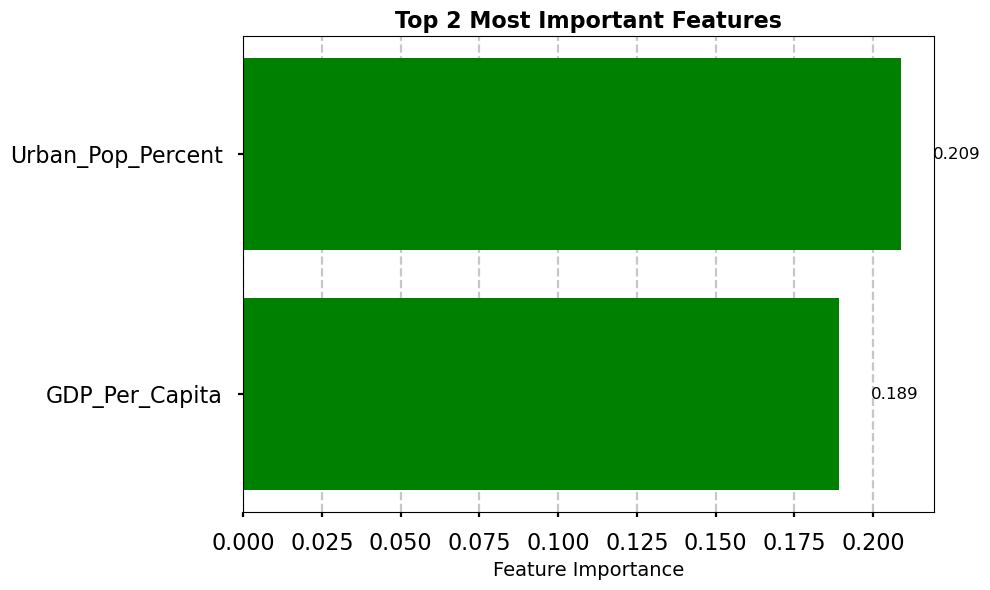

```python
# Prepare Data
# Drop non-numeric columns and target variable
X = obesity_world_enricheddata.drop(columns=['Country', 'Year', 'Obesity'])
y = obesity_world_enricheddata['Obesity']

# Train-Test Split
X_train, X_test, y_train, y_test = train_test_split(X, y, test_size=0.3, stratify=y, random_state=42)

# Standardize Features
scaler = StandardScaler().fit(X_train)
X_train_scaled = scaler.transform(X_train)
X_test_scaled = scaler.transform(X_test)

# Train Random Forest for Feature Importance
rf_model = RandomForestClassifier(random_state=42)
rf_model.fit(X_train_scaled, y_train)

# Get feature importances and sort
importances = rf_model.feature_importances_
indices = np.argsort(importances)[::-1]

# Select top 2 features
top_k = 2
top_features = X.columns[indices[:top_k]]
top_importances = importances[indices[:top_k]]

# Create a DataFrame for top features
top_features_df = pd.DataFrame({
    'Feature': top_features,
    'Importance': top_importances
}).sort_values('Importance', ascending=True)

# Plot
plt.style.use('seaborn-v0_8-poster')
fig, ax = plt.subplots(figsize=(10, 6))
bars = ax.barh(top_features_df['Feature'], top_features_df['Importance'], color='green')

# Add importance values on bars
for bar in bars:
    width = bar.get_width()
    ax.text(width + 0.01, bar.get_y() + bar.get_height() / 2,
            f'{width:.3f}', va='center', fontsize=12, color='black')

ax.set_xlabel('Feature Importance', fontsize=14)
ax.set_title('Top 2 Most Important Features', fontsize=16, weight='bold')
ax.grid(True, axis='x', linestyle='--', alpha=0.7)
ax.set_axisbelow(True)
plt.tight_layout()
plt.show()
```

```
Tuned Polynomial SVM (C=1, degree=2, gamma='scale')

Training Accuracy: 0.6875
Training Error: 0.3125
Test Accuracy: 0.4667
Test Error: 0.5333

Confusion Matrix:
           Predicted: 0  Predicted: 1
Actual: 0             3             5
Actual: 1             3             4

Classification Report:
               precision    recall  f1-score   support

           0       0.50      0.38      0.43         8
           1       0.44      0.57      0.50         7

    accuracy                           0.47        15
   macro avg       0.47      0.47      0.46        15
weighted avg       0.47      0.47      0.46        15
```

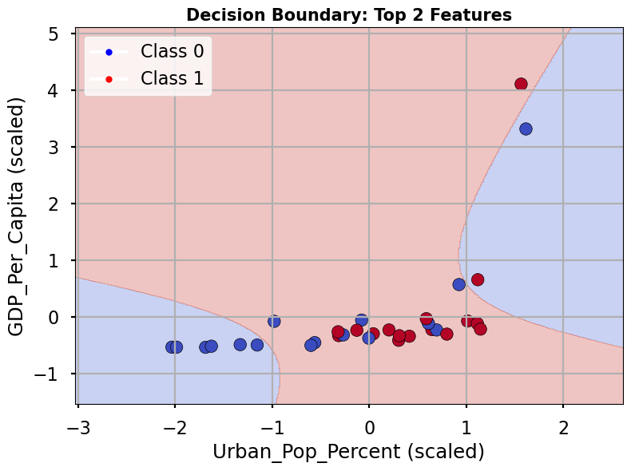

```python
# Polynomial SVM with Decision Boundary Visualization

# Select top 2 features and target
features_2top = ['Urban_Pop_Percent', 'GDP_Per_Capita']
X = obesity_world_enricheddata[features_2top]
y = obesity_world_enricheddata['Obesity']

# Split data
X_train, X_test, y_train, y_test = train_test_split(
    X, y, test_size=0.3, stratify=y, random_state=42
)

# Standardize features
scaler = StandardScaler()
X_train_scaled = scaler.fit_transform(X_train)
X_test_scaled = scaler.transform(X_test)

# Train tuned Polynomial SVM
poly_svm = SVC(kernel='poly', C=1, degree=2, gamma='scale', random_state=42)
poly_svm.fit(X_train_scaled, y_train)

# Evaluate performance
y_pred = poly_svm.predict(X_test_scaled)
train_acc = poly_svm.score(X_train_scaled, y_train)
test_acc = poly_svm.score(X_test_scaled, y_test)
train_err = 1 - train_acc
test_err = 1 - test_acc

# Print results
print("Tuned Polynomial SVM (C=1, degree=2, gamma='scale')\n")
print(f"Training Accuracy: {train_acc:.4f}")
print(f"Training Error: {train_err:.4f}")
print(f"Test Accuracy: {test_acc:.4f}")
print(f"Test Error: {test_err:.4f}")
print("\nConfusion Matrix:")
print(pd.DataFrame(confusion_matrix(y_test, y_pred),
                   index=['Actual: 0', 'Actual: 1'],
                   columns=['Predicted: 0', 'Predicted: 1']))
print("\nClassification Report:\n", classification_report(y_test, y_pred))

# Plot decision boundary
x_min, x_max = X_train_scaled[:, 0].min() - 1, X_train_scaled[:, 0].max() + 1
y_min, y_max = X_train_scaled[:, 1].min() - 1, X_train_scaled[:, 1].max() + 1
xx, yy = np.meshgrid(np.linspace(x_min, x_max, 500),
                     np.linspace(y_min, y_max, 500))

Z = poly_svm.predict(np.c_[xx.ravel(), yy.ravel()])
Z = Z.reshape(xx.shape)

plt.figure(figsize=(8, 6))
plt.contourf(xx, yy, Z, alpha=0.3, cmap='coolwarm')
plt.scatter(X_train_scaled[:, 0], X_train_scaled[:, 1], c=y_train, cmap='coolwarm', edgecolors='k')
plt.xlabel('Urban_Pop_Percent (scaled)')
plt.ylabel('GDP_Per_Capita (scaled)')
plt.title('Decision Boundary: Top 2 Features', fontsize=15, weight='bold')
plt.xlim(xx.min(), xx.max())
plt.ylim(yy.min(), yy.max())

# Legend
from matplotlib.lines import Line2D
legend_elements = [
    Line2D([0], [0], marker='o', color='w', label='Class 0', markerfacecolor='blue', markersize=6),
    Line2D([0], [0], marker='o', color='w', label='Class 1', markerfacecolor='red', markersize=6)
]
plt.legend(handles=legend_elements)

plt.grid(True)
plt.tight_layout()
plt.show()
```

```python
# Dataset only Top 2 Features
X_train_top2 = X_train[top_features]
X_test_top2 = X_test[top_features]

# Standardize Again for Top 2 Features
scaler_top2 = StandardScaler().fit(X_train_top2)
X_train_top2_scaled = scaler_top2.transform(X_train_top2)
X_test_top2_scaled = scaler_top2.transform(X_test_top2)

# Tuned SVM Models

# Tuned Linear SVM
linear_svm = SVC(kernel='linear', probability=True, random_state=42)
param_grid_linear = {'C': [0.1, 1, 10, 100]}
grid_linear = GridSearchCV(linear_svm, param_grid_linear, cv=5, scoring='accuracy', n_jobs=-1, verbose=2)
grid_linear.fit(X_train_top2_scaled, y_train)
best_linear_svm = grid_linear.best_estimator_
print("Best Linear SVM Parameters:", grid_linear.best_params_)

# Tuned Radial SVM
radial_svm = SVC(kernel='rbf', probability=True, random_state=42)
param_grid_radial = {'C': [0.1, 1, 10, 100], 'gamma': ['scale', 0.01, 0.1, 1]}
grid_radial = GridSearchCV(radial_svm, param_grid_radial, cv=5, scoring='accuracy', n_jobs=-1, verbose=2)
grid_radial.fit(X_train_top2_scaled, y_train)
best_radial_svm = grid_radial.best_estimator_
print("Best Radial SVM Parameters:", grid_radial.best_params_)

# Tuned Polynomial SVM
poly_svm = SVC(kernel='poly', probability=True, random_state=42)
param_grid_poly = {'C': [0.1, 1, 10], 'gamma': ['scale', 0.01, 0.1], 'degree': [2, 3, 4]}
grid_poly = GridSearchCV(poly_svm, param_grid_poly, cv=5, scoring='accuracy', n_jobs=-1, verbose=2)
grid_poly.fit(X_train_top2_scaled, y_train)
best_poly_svm = grid_poly.best_estimator_
print("Best Polynomial SVM Parameters:", grid_poly.best_params_)

# Voting Classifier
voting_svm = VotingClassifier(
    estimators=[
        ('linear_svm', best_linear_svm),
        ('radial_svm', best_radial_svm),
        ('poly_svm', best_poly_svm)
    ],
    voting='soft'
)

# Train Voting Classifier
voting_svm.fit(X_train_top2_scaled, y_train)

# Train and Test Predictions
y_train_pred = voting_svm.predict(X_train_top2_scaled)
y_test_pred = voting_svm.predict(X_test_top2_scaled)

# Accuracy and Error
train_accuracy = accuracy_score(y_train, y_train_pred)
test_accuracy = accuracy_score(y_test, y_test_pred)

train_error = 1 - train_accuracy
test_error = 1 - test_accuracy

# Results
print(f"\nTraining Accuracy: {train_accuracy:.4f}")
print(f"Training Error: {train_error:.4f}")
print(f"Testing Accuracy: {test_accuracy:.4f}")
print(f"Testing Error: {test_error:.4f}")

# Evaluate Test Set
print("\nSoft Voting SVM Classifier Accuracy (Test Set):", test_accuracy)
print("\nClassification Report (Test Set):\n", classification_report(y_test, y_test_pred))
print("Confusion Matrix (Test Set):\n", confusion_matrix(y_test, y_test_pred))
print("\nConfusion Matrix (Test Set):")
print(pd.DataFrame(confusion_matrix(y_test, y_test_pred),
                   index=['Actual: 0', 'Actual: 1'],
                   columns=['Predicted: 0', 'Predicted: 1']))
```

```
Fitting 5 folds for each of 4 candidates, totalling 20 fits
Best Linear SVM Parameters: {'C': 0.1}
Fitting 5 folds for each of 16 candidates, totalling 80 fits
Best Radial SVM Parameters: {'C': 10, 'gamma': 0.01}
Fitting 5 folds for each of 27 candidates, totalling 135 fits
Best Polynomial SVM Parameters: {'C': 10, 'degree': 2, 'gamma': 'scale'}

Training Accuracy: 0.7500
Training Error: 0.2500
Testing Accuracy: 0.8000
Testing Error: 0.2000

Soft Voting SVM Classifier Accuracy (Test Set): 0.8

Classification Report (Test Set):
               precision    recall  f1-score   support

           0       0.78      0.88      0.82         8
           1       0.83      0.71      0.77         7

    accuracy                           0.80        15
   macro avg       0.81      0.79      0.80        15
weighted avg       0.80      0.80      0.80        15

Confusion Matrix (Test Set):
 [[7 1]
 [2 5]]

Confusion Matrix (Test Set):
           Predicted: 0  Predicted: 1
Actual: 0             7             1
Actual: 1             2             5
```

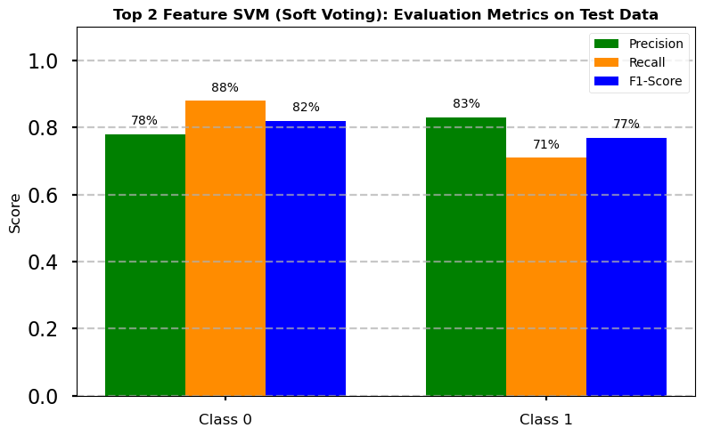

```python
# Evaluation Metrics for Top 2 Feature Soft Voting Tuned SVM on Test Data
classes = ['Class 0', 'Class 1']
precision = [0.78, 0.83]
recall = [0.88, 0.71]
f1_score = [0.82, 0.77]

x = np.arange(len(classes))
bar_width = 0.25

fig, ax = plt.subplots(figsize=(8, 5))

# Plotting the bars
bars1 = ax.bar(x - bar_width, precision, width=bar_width, label='Precision', color='green')
bars2 = ax.bar(x, recall, width=bar_width, label='Recall', color='darkorange')
bars3 = ax.bar(x + bar_width, f1_score, width=bar_width, label='F1-Score', color='blue')

# Annotate the bars with percentages
for bars in [bars1, bars2, bars3]:
    for bar in bars:
        height = bar.get_height()
        ax.text(bar.get_x() + bar.get_width() / 2, height + 0.02,
                f'{height * 100:.0f}%', ha='center', va='bottom', fontsize=10)

# Formatting
ax.set_ylabel('Score', fontsize=12)
ax.set_title('Top 2 Feature SVM (Soft Voting): Evaluation Metrics on Test Data', fontsize=12, fontweight='bold')
ax.set_xticks(x)
ax.set_xticklabels(classes, fontsize=12)
ax.set_ylim(0, 1.1)
ax.legend(fontsize=10)
ax.grid(axis='y', linestyle='--', alpha=0.7)

plt.tight_layout()
plt.show()
```

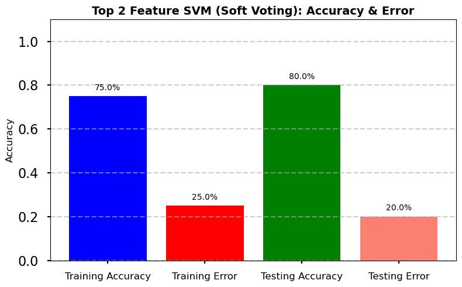

```python
# Metrics and values
metrics = ['Training Accuracy', 'Training Error', 'Testing Accuracy', 'Testing Error']
values = [0.7500, 0.2500, 0.8000, 0.2000]
colors = ['blue', 'red', 'green', 'salmon']

# Create bar chart
fig, ax = plt.subplots(figsize=(8, 5))
bars = ax.bar(metrics, values, color=colors)

# Annotate bars with percentage
for bar in bars:
    height = bar.get_height()
    ax.text(bar.get_x() + bar.get_width() / 2, height + 0.02,
            f'{height * 100:.1f}%', ha='center', va='bottom', fontsize=10)

# Formatting
ax.set_ylim(0, 1.1)
ax.set_ylabel('Accuracy', fontsize=12)
ax.set_title('Top 2 Feature SVM (Soft Voting): Accuracy & Error', fontsize=14, fontweight='bold')
ax.set_xticklabels(metrics, fontsize=12)
ax.grid(axis='y', linestyle='--', alpha=0.6)

plt.tight_layout()
plt.show()
```

Result: The "soft" voting SVM classifier achieved a test accuracy of 80%, indicating good generalization. The model performed slightly better on class 0 non-obesity (F1-score: 82%) than class 1 obesity (F1-score: 77%), showing some imbalance in recall. The confusion matrix reveals that only 3 out of 15 predictions were misclassified, confirming solid overall performance. This suggests that combining tuned SVM models via soft voting improves classification effectiveness across both classes.

## 3.3.6 Tuned SVM Ensemble with Hard Voting on Top 2 Selected Features¶

```python
# Dataset only Top 2 Features
X_train_top2 = X_train[top_features]
X_test_top2 = X_test[top_features]

# Standardize Again for Top 2 Features
scaler_top2 = StandardScaler().fit(X_train_top2)
X_train_top2_scaled = scaler_top2.transform(X_train_top2)
X_test_top2_scaled = scaler_top2.transform(X_test_top2)

# Tuned SVM Models

# Tuned Linear SVM
linear_svm = SVC(kernel='linear', probability=True, random_state=42)
param_grid_linear = {'C': [0.1, 1, 10, 100]}
grid_linear = GridSearchCV(linear_svm, param_grid_linear, cv=5, scoring='accuracy', n_jobs=-1, verbose=2)
grid_linear.fit(X_train_top2_scaled, y_train)
best_linear_svm = grid_linear.best_estimator_
print("Best Linear SVM Parameters:", grid_linear.best_params_)

# Tuned Radial SVM
radial_svm = SVC(kernel='rbf', probability=True, random_state=42)
param_grid_radial = {'C': [0.1, 1, 10, 100], 'gamma': ['scale', 0.01, 0.1, 1]}
grid_radial = GridSearchCV(radial_svm, param_grid_radial, cv=5, scoring='accuracy', n_jobs=-1, verbose=2)
grid_radial.fit(X_train_top2_scaled, y_train)
best_radial_svm = grid_radial.best_estimator_
print("Best Radial SVM Parameters:", grid_radial.best_params_)

# Tuned Polynomial SVM
poly_svm = SVC(kernel='poly', probability=True, random_state=42)
param_grid_poly = {'C': [0.1, 1, 10], 'gamma': ['scale', 0.01, 0.1], 'degree': [2, 3, 4]}
grid_poly = GridSearchCV(poly_svm, param_grid_poly, cv=5, scoring='accuracy', n_jobs=-1, verbose=2)
grid_poly.fit(X_train_top2_scaled, y_train)
best_poly_svm = grid_poly.best_estimator_
print("Best Polynomial SVM Parameters:", grid_poly.best_params_)

# Voting Classifier
voting_svm = VotingClassifier(
    estimators=[
        ('linear_svm', best_linear_svm),
        ('radial_svm', best_radial_svm),
        ('poly_svm', best_poly_svm)
    ],
    voting='hard'
)

# Train Voting Classifier
voting_svm.fit(X_train_top2_scaled, y_train)

# Train and Test Predictions
y_train_pred = voting_svm.predict(X_train_top2_scaled)
y_test_pred = voting_svm.predict(X_test_top2_scaled)

# Accuracy and Error
train_accuracy = accuracy_score(y_train, y_train_pred)
test_accuracy = accuracy_score(y_test, y_test_pred)

train_error = 1 - train_accuracy
test_error = 1 - test_accuracy

# Results
print(f"\nTraining Accuracy: {train_accuracy:.4f}")
print(f"Training Error: {train_error:.4f}")
print(f"Testing Accuracy: {test_accuracy:.4f}")
print(f"Testing Error: {test_error:.4f}")

# Evaluate Test Set
print("\nHard Voting SVM Classifier Accuracy (Test Set):", test_accuracy)
print("\nClassification Report (Test Set):\n", classification_report(y_test, y_test_pred))
print("Confusion Matrix (Test Set):\n", confusion_matrix(y_test, y_test_pred))
print("\nConfusion Matrix (Test Set):")
print(pd.DataFrame(confusion_matrix(y_test, y_test_pred),
                   index=['Actual: 0', 'Actual: 1'],
                   columns=['Predicted: 0', 'Predicted: 1']))
```

```
Fitting 5 folds for each of 4 candidates, totalling 20 fits
Best Linear SVM Parameters: {'C': 0.1}
Fitting 5 folds for each of 16 candidates, totalling 80 fits
Best Radial SVM Parameters: {'C': 10, 'gamma': 0.01}
Fitting 5 folds for each of 27 candidates, totalling 135 fits
Best Polynomial SVM Parameters: {'C': 10, 'degree': 2, 'gamma': 'scale'}

Training Accuracy: 0.7500
Training Error: 0.2500
Testing Accuracy: 0.7333
Testing Error: 0.2667

Hard Voting SVM Classifier Accuracy (Test Set): 0.7333333333333333

Classification Report (Test Set):
               precision    recall  f1-score   support

           0       0.75      0.75      0.75         8
           1       0.71      0.71      0.71         7

    accuracy                           0.73        15
   macro avg       0.73      0.73      0.73        15
weighted avg       0.73      0.73      0.73        15

Confusion Matrix (Test Set):
 [[6 2]
 [2 5]]

Confusion Matrix (Test Set):
           Predicted: 0  Predicted: 1
Actual: 0             6             2
Actual: 1             2             5
```

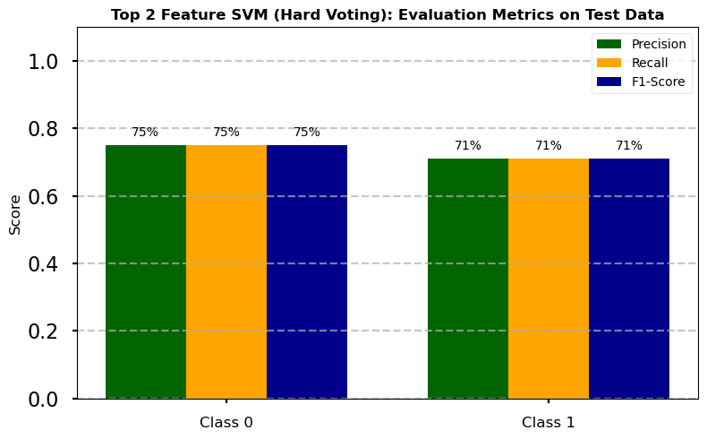

```python
# Evaluation Metrics for Top 2 Feature Hard Voting Tuned SVM on Test Data
classes = ['Class 0', 'Class 1']
precision = [0.75, 0.71]
recall = [0.75, 0.71]
f1_score = [0.75, 0.71]

x = np.arange(len(classes))
bar_width = 0.25

fig, ax = plt.subplots(figsize=(8, 5))

# Plotting the bars
bars1 = ax.bar(x - bar_width, precision, width=bar_width, label='Precision', color='darkgreen')
bars2 = ax.bar(x, recall, width=bar_width, label='Recall', color='orange')
bars3 = ax.bar(x + bar_width, f1_score, width=bar_width, label='F1-Score', color='darkblue')

# Annotate the bars with percentages
for bars in [bars1, bars2, bars3]:
    for bar in bars:
        height = bar.get_height()
        ax.text(bar.get_x() + bar.get_width() / 2, height + 0.02,
                f'{height * 100:.0f}%', ha='center', va='bottom', fontsize=10)

# Formatting
ax.set_ylabel('Score', fontsize=12)
ax.set_title('Top 2 Feature SVM (Hard Voting): Evaluation Metrics on Test Data', fontsize=12, fontweight='bold')
ax.set_xticks(x)
ax.set_xticklabels(classes, fontsize=12)
ax.set_ylim(0, 1.1)
ax.legend(fontsize=10)
ax.grid(axis='y', linestyle='--', alpha=0.7)

plt.tight_layout()
plt.show()
```

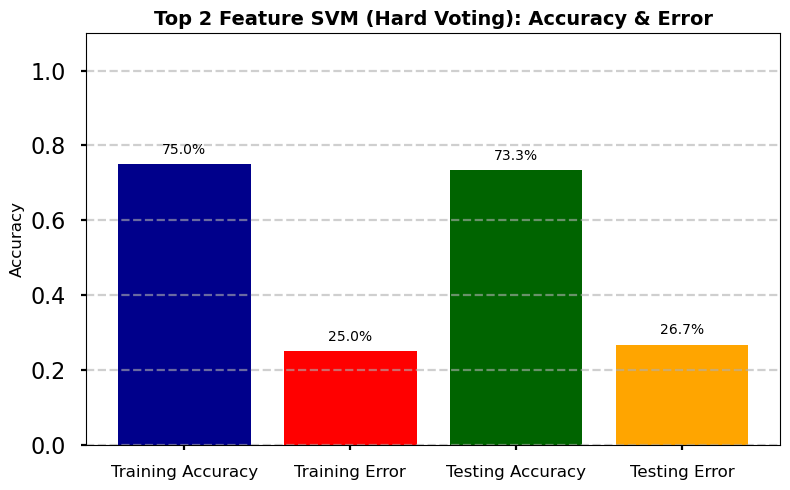

```python
# Metrics and values
metrics = ['Training Accuracy', 'Training Error', 'Testing Accuracy', 'Testing Error']
values = [0.7500, 0.2500, 0.7333, 0.2667]
colors = ['darkblue', 'red', 'darkgreen', 'orange']

# Create bar chart
fig, ax = plt.subplots(figsize=(8, 5))
bars = ax.bar(metrics, values, color=colors)

# Annotate bars with percentage
for bar in bars:
    height = bar.get_height()
    ax.text(bar.get_x() + bar.get_width() / 2, height + 0.02,
            f'{height * 100:.1f}%', ha='center', va='bottom', fontsize=10)

# Formatting
ax.set_ylim(0, 1.1)
ax.set_ylabel('Accuracy', fontsize=12)
ax.set_title('Top 2 Feature SVM (Hard Voting): Accuracy & Error', fontsize=14, fontweight='bold')
ax.set_xticklabels(metrics, fontsize=12)
ax.grid(axis='y', linestyle='--', alpha=0.6)

plt.tight_layout()
plt.show()
```

Result: The hard voting ensemble of tuned SVM models using the top 2 features achieved a test accuracy of 73.3%, demonstrating solid overall performance. Precision, recall, and F1-scores were balanced across both classes (all ≈ 73%–75%), indicating consistent classification. The confusion matrix shows that 4 out of 15 test samples were misclassified, suggesting room for improvement but a generally effective ensemble model. This result confirms that a small, well-selected feature set can still yield meaningful predictive performance when paired with tuned SVMs and ensemble methods.

# 3.3.9 Comparisan Results All of SVM Models

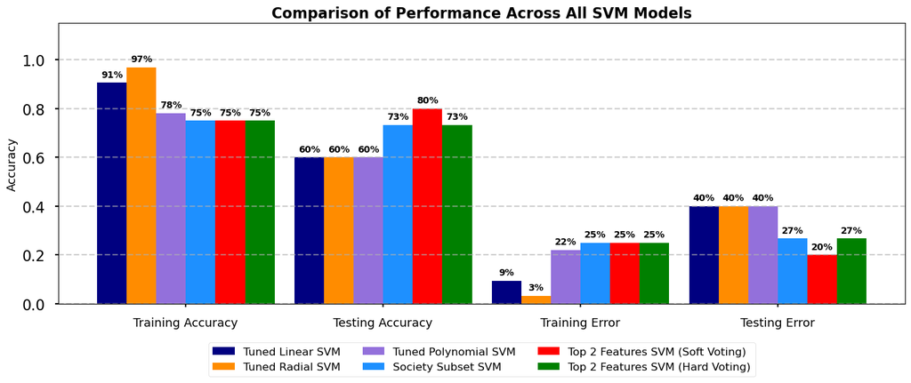

```python
# Models and Metrics
models = [
    'Tuned Linear SVM',
    'Tuned Radial SVM',
    'Tuned Polynomial SVM',
    'Society Subset SVM',
    'Top 2 Features SVM (Soft Voting)',
    'Top 2 Features SVM (Hard Voting)'
]

metrics = ['Training Accuracy', 'Testing Accuracy', 'Training Error', 'Testing Error']

# Values per model
values = np.array([
    [0.9062, 0.9688, 0.7812, 0.7500, 0.7500, 0.7500],  # Training Accuracy
    [0.6000, 0.6000, 0.6000, 0.7333, 0.8000, 0.7333],  # Testing Accuracy
    [0.0938, 0.0312, 0.2188, 0.2500, 0.2500, 0.2500],  # Training Error
    [0.4000, 0.4000, 0.4000, 0.2667, 0.2000, 0.2667]   # Testing Error
])

# Setup
n_metrics = len(metrics)
n_models = len(models)
x = np.arange(n_metrics)
bar_width = 0.15
total_width = bar_width * n_models
offsets = np.linspace(-total_width / 2 + bar_width / 2, total_width / 2 - bar_width / 2, n_models)

colors = ['navy', 'darkorange', 'mediumpurple', 'dodgerblue', 'red', 'green']

fig, ax = plt.subplots(figsize=(14, 6))

# Plot each model across all metrics
for i in range(n_models):
    bar_positions = x + offsets[i]
    bars = ax.bar(bar_positions, values[:, i], width=bar_width, label=models[i], color=colors[i])

    # Add rounded percentage label
    for bar in bars:
        height = bar.get_height()
        ax.text(bar.get_x() + bar.get_width() / 2, height + 0.015,
                f'{round(height * 100)}%', ha='center', va='bottom',
                fontsize=10, fontweight='bold')

# Formatting
ax.set_ylabel('Accuracy', fontsize=13)
ax.set_title('Comparison of Performance Across All SVM Models', fontsize=16, fontweight='bold')
ax.set_xticks(x)
ax.set_xticklabels(metrics, fontsize=13)
ax.set_ylim(0, 1.15)
ax.legend(fontsize=12, loc='upper center', bbox_to_anchor=(0.5, -0.12), ncol=3)
ax.grid(axis='y', linestyle='--', alpha=0.6)

plt.tight_layout()
plt.show()
```

Result: Our SVM models produced the results shown above. Among all SVM models, the Top 2 Features SVM with Soft Voting achieved the highest testing accuracy (80%) and the lowest testing error (20%), demonstrating the most effective generalization. While the Tuned Radial SVM had the highest training accuracy (97%), it suffered from higher testing error (40%), suggesting overfitting. Overall, ensemble methods using a reduced feature set outperformed individual models, highlighting the strength of feature selection combined with voting strategies for improving SVM performance.

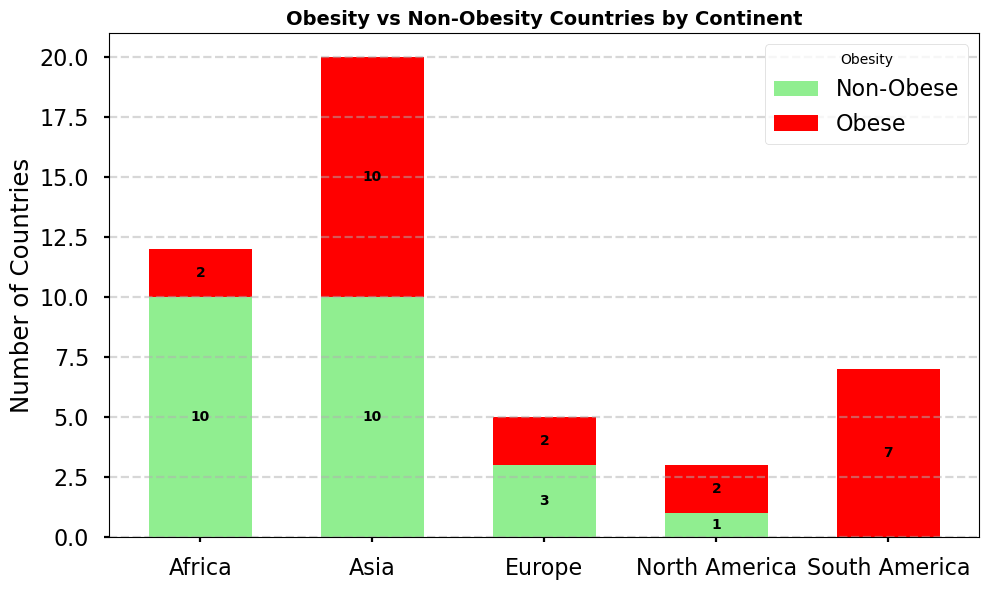

```python
# Dataset copy
df = obesity_world_enricheddata.copy()

# Continent mapping
continent_map = {
    'Afghanistan': 'Asia', 'Algeria': 'Africa', 'Argentina': 'South America', 'Armenia': 'Asia',
    'Azerbaijan': 'Asia', 'Bahrain': 'Asia', 'Belarus': 'Europe', 'Benin': 'Africa',
    'Bolivia': 'South America', 'Brazil': 'South America', 'China': 'Asia', 'Colombia': 'South America',
    'Cuba': 'North America', 'Ecuador': 'South America', 'Georgia': 'Asia', 'Guyana': 'South America',
    'Iraq': 'Asia', 'Italy': 'Europe', 'Jordan': 'Asia', 'Lebanon': 'Asia', 'Liberia': 'Africa',
    'Malawi': 'Africa', 'Malaysia': 'Asia', 'Mauritius': 'Africa', 'Moldova': 'Europe',
    'Morocco': 'Africa', 'Niger': 'Africa', 'North Macedonia': 'Europe', 'Oman': 'Asia',
    'Pakistan': 'Asia', 'Panama': 'North America', 'Peru': 'South America', 'Qatar': 'Asia',
    'Rwanda': 'Africa', 'Saudi Arabia': 'Asia', 'Singapore': 'Asia', 'South Africa': 'Africa',
    'Sri Lanka': 'Asia', 'Sudan': 'Africa', 'Tajikistan': 'Asia', 'Trinidad and Tobago': 'North America',
    'Turkmenistan': 'Asia', 'Uganda': 'Africa', 'Ukraine': 'Europe', 'United Arab Emirates': 'Asia',
    'Uzbekistan': 'Asia', 'Zambia': 'Africa'
}

# Map continent
df['Continent'] = df['Country'].map(continent_map)

# Drop unmapped countries
df = df.dropna(subset=['Continent'])

# Group by continent and obesity class
grouped = df.groupby(['Continent', 'Obesity'])['Country'].count().reset_index()

# Pivot
pivot = grouped.pivot(index='Continent', columns='Obesity', values='Country').fillna(0)
pivot.columns = ['Non-Obese', 'Obese']
pivot = pivot.astype(int)

# Plot stacked bar chart
fig, ax = plt.subplots(figsize=(10, 6))
x = np.arange(len(pivot))
width = 0.6

bottom = np.zeros(len(x))
colors = ['lightgreen', 'red']
labels = ['Non-Obese', 'Obese']

for i, label in enumerate(labels):
    bar_heights = pivot[label].values
    ax.bar(x, bar_heights, width=width, bottom=bottom, color=colors[i], label=label)

    for j, height in enumerate(bar_heights):
        if height > 0:
            ax.text(j, bottom[j] + height / 2, f'{int(height)}',
                    ha='center', va='center', fontsize=10, fontweight='bold')
    bottom += bar_heights

# Labels and title
ax.set_xticks(x)
ax.set_xticklabels(pivot.index)
ax.set_ylabel("Number of Countries")
ax.set_title("Obesity vs Non-Obesity Countries by Continent", fontsize=14, fontweight='bold')
ax.legend(title="Obesity")
ax.grid(axis='y', linestyle='--', alpha=0.5)

plt.tight_layout()
plt.show()
```

Result: South America and North America have a higher concentration of countries with obesity, while Africa and Asia show a more balanced or non-obese leaning distribution.